# CRAN

Dado mais recente: **18 set 2026**Página construída em 19 set 2026, 11:30 UTC. Todo gráfico abaixo é datado pelo seu dado, nunca por este build.

Status de check por pacote e flavor, a amostra diária de downloads com marcadores de release e o histórico completo de versões.

## Estado dos pacotes

Snapshot de 19 set 2026

| Pacote | Pior status | Flavors verificados | Flavors fora de OK | No CRAN | Arquivado | Mantenedor |
| --- | --- | --- | --- | --- | --- | --- |
| betaregscale | ✓OK, status de check: check passou em todos os flavors | 13 | 0 | sim | não | José Evandeilton Lopes |
| gkwdist | ✓OK, status de check: check passou em todos os flavors | 13 | 0 | sim | não | José Evandeilton Lopes |
| gkwreg | ✓OK, status de check: check passou em todos os flavors | 13 | 0 | sim | não | José Evandeilton Lopes |
| OptimalBinningWoE | ✓OK, status de check: check passou em todos os flavors | 13 | 0 | sim | não | José Evandeilton Lopes |

## Status de check por pacote e flavor

Uma coluna por flavor de check do CRAN, apenas o snapshot mais recente. O status é dado por texto, nunca apenas por cor.

Snapshot de 19 set 2026

| Flavor | betaregscale | gkwdist | gkwreg | OptimalBinningWoE |
| --- | --- | --- | --- | --- |
| r-devel-linux-x86_64-debian-clang | ✓OK, status de check: check passou em todos os flavors | ✓OK, status de check: check passou em todos os flavors | ✓OK, status de check: check passou em todos os flavors | ✓OK, status de check: check passou em todos os flavors |
| r-devel-linux-x86_64-debian-gcc | ✓OK, status de check: check passou em todos os flavors | ✓OK, status de check: check passou em todos os flavors | ✓OK, status de check: check passou em todos os flavors | ✓OK, status de check: check passou em todos os flavors |
| r-devel-linux-x86_64-fedora-clang | ✓OK, status de check: check passou em todos os flavors | ✓OK, status de check: check passou em todos os flavors | ✓OK, status de check: check passou em todos os flavors | ✓OK, status de check: check passou em todos os flavors |
| r-devel-linux-x86_64-fedora-gcc | ✓OK, status de check: check passou em todos os flavors | ✓OK, status de check: check passou em todos os flavors | ✓OK, status de check: check passou em todos os flavors | ✓OK, status de check: check passou em todos os flavors |
| r-devel-windows-x86_64 | ✓OK, status de check: check passou em todos os flavors | ✓OK, status de check: check passou em todos os flavors | ✓OK, status de check: check passou em todos os flavors | ✓OK, status de check: check passou em todos os flavors |
| r-oldrel-macos-arm64 | ✓OK, status de check: check passou em todos os flavors | ✓OK, status de check: check passou em todos os flavors | ✓OK, status de check: check passou em todos os flavors | ✓OK, status de check: check passou em todos os flavors |
| r-oldrel-macos-x86_64 | ✓OK, status de check: check passou em todos os flavors | ✓OK, status de check: check passou em todos os flavors | ✓OK, status de check: check passou em todos os flavors | ✓OK, status de check: check passou em todos os flavors |
| r-oldrel-windows-x86_64 | ✓OK, status de check: check passou em todos os flavors | ✓OK, status de check: check passou em todos os flavors | ✓OK, status de check: check passou em todos os flavors | ✓OK, status de check: check passou em todos os flavors |
| r-patched-linux-x86_64 | ✓OK, status de check: check passou em todos os flavors | ✓OK, status de check: check passou em todos os flavors | ✓OK, status de check: check passou em todos os flavors | ✓OK, status de check: check passou em todos os flavors |
| r-release-linux-x86_64 | ✓OK, status de check: check passou em todos os flavors | ✓OK, status de check: check passou em todos os flavors | ✓OK, status de check: check passou em todos os flavors | ✓OK, status de check: check passou em todos os flavors |
| r-release-macos-arm64 | ✓OK, status de check: check passou em todos os flavors | ✓OK, status de check: check passou em todos os flavors | ✓OK, status de check: check passou em todos os flavors | ✓OK, status de check: check passou em todos os flavors |
| r-release-macos-x86_64 | ✓OK, status de check: check passou em todos os flavors | ✓OK, status de check: check passou em todos os flavors | ✓OK, status de check: check passou em todos os flavors | ✓OK, status de check: check passou em todos os flavors |
| r-release-windows-x86_64 | ✓OK, status de check: check passou em todos os flavors | ✓OK, status de check: check passou em todos os flavors | ✓OK, status de check: check passou em todos os flavors | ✓OK, status de check: check passou em todos os flavors |

Tempo de check (s)

| Pacote | Versão | Tempo de check (s) |
| --- | --- | --- |
| betaregscale | 2.7.4 | 175,5 |
| gkwdist | 1.1.5 | 129,4 |
| gkwreg | 2.1.18 | 180,0 |
| OptimalBinningWoE | 1.13.5 | 181,7 |

## Downloads diários

ⓘ **downloads do mirror da Posit (amostra parcial)**. Por que isto é uma amostra parcial e não um total de downloads.

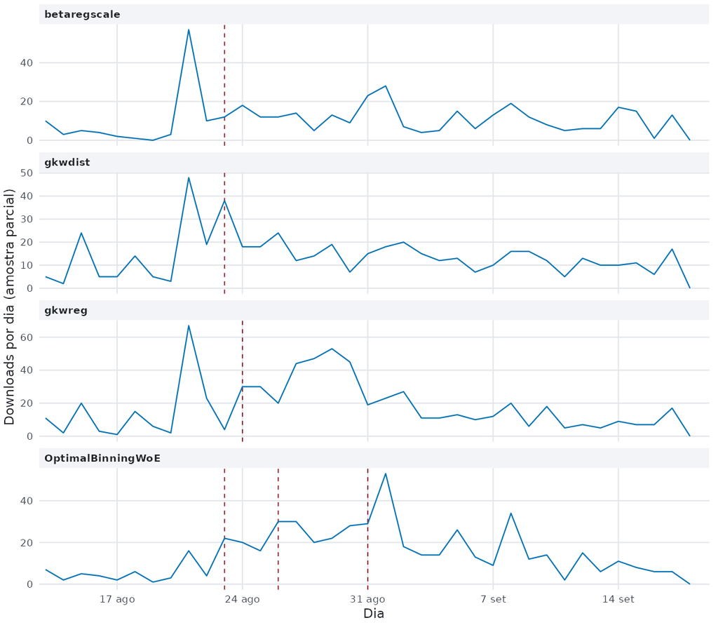

Dados do gráfico até 18 set 2026. Janela exportada: 19 set 2025 a 18 set 2026.

Amostra de downloads por pacote — downloads do mirror da Posit (amostra parcial)

| Pacote | Downloads |
| --- | --- |
| betaregscale | 393 |
| gkwdist | 506 |
| gkwreg | 650 |
| OptimalBinningWoE | 528 |

## Arquivo mensal permanente

Rollup mensal, mantido indefinidamente. A série diária acima é podada para uma janela móvel de 12 meses.

ⓘ **downloads do mirror da Posit (amostra parcial)**. Por que isto é uma amostra parcial e não um total de downloads.

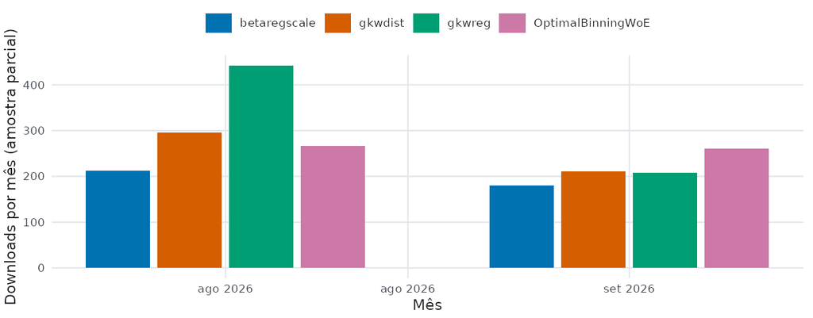

Arquivo mensal permanente — downloads do mirror da Posit (amostra parcial)

| Mês | Pacote | Downloads |
| --- | --- | --- |
| ago 2026 | betaregscale | 213 |
| ago 2026 | gkwdist | 295 |
| ago 2026 | gkwreg | 442 |
| ago 2026 | OptimalBinningWoE | 267 |
| set 2026 | betaregscale | 180 |
| set 2026 | gkwdist | 211 |
| set 2026 | gkwreg | 208 |
| set 2026 | OptimalBinningWoE | 261 |

## Histórico de versões

Tabela permanente: todas as versões publicadas no CRAN, da mais recente para a mais antiga.

| Pacote | Versão | Data de publicação | Vigente |
| --- | --- | --- | --- |
| OptimalBinningWoE | 1.13.5 | 31 ago 2026 | sim |
| OptimalBinningWoE | 1.13.4 | 26 ago 2026 | não |
| OptimalBinningWoE | 1.13.3 | 23 ago 2026 | não |
| OptimalBinningWoE | 1.0.8 | 29 jan 2026 | não |
| OptimalBinningWoE | 1.0.3 | 23 jan 2026 | não |
| betaregscale | 2.7.4 | 23 ago 2026 | sim |
| betaregscale | 2.6.9 | 25 fev 2026 | não |
| gkwdist | 1.1.5 | 23 ago 2026 | sim |
| gkwdist | 1.1.4 | 28 mai 2026 | não |
| gkwdist | 1.1.3 | 21 mai 2026 | não |
| gkwdist | 1.1.2 | 8 jan 2026 | não |
| gkwdist | 1.1.1 | 27 nov 2025 | não |
| gkwdist | 1.0.10 | 13 nov 2025 | não |
| gkwreg | 2.1.18 | 24 ago 2026 | sim |
| gkwreg | 2.1.14 | 9 jan 2026 | não |
| gkwreg | 2.1.6 | 27 nov 2025 | não |
| gkwreg | 2.1.1 | 15 nov 2025 | não |
| gkwreg | 1.0.10 | 9 jul 2025 | não |
| gkwreg | 1.0.7 | 1 mai 2025 | não |
| gkwreg | 1.0.3 | 15 abr 2025 | não |